# Predicting End of Season Batting Averages

Diego Martinez

10/30/2019

# Data Checking and Acquisition

I began by taking an overall look at the data in the batting.csv. I first checked for any NA values in any of the columns. These could negatively affect a model, thus if there are any, I would like to know.

```r
#checking for any Na values in any of the columns of dataset

batting %>%
  mutate(`Any Na` = apply(batting, 1, anyNA)) %>%
  count(`Any Na`)%>%
  #cretes a nicer output table
  gt()
```

| Any Na | n |
| --- | --- |
| FALSE | 309 |

From the looks of it, I will not have to worry about filling in any Na values and the data is complete for every player.

Now, I would like to take a look at the distribution of a few columns I believe will be important for the analysis such as the March and April batting averages. I also take a look at the components of Batting Average, Hits and At Bats, to provide more context to the Batting Averages. For example hitting 0.400 is amazing, but if the sample size is 2 hits in 5 at bats, the Batting Average looks less appealing.

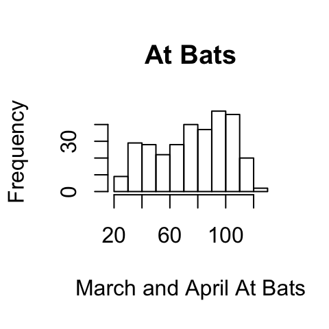

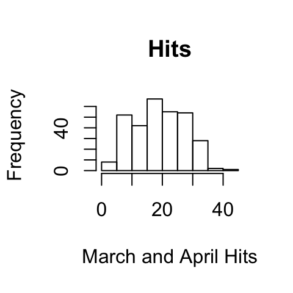

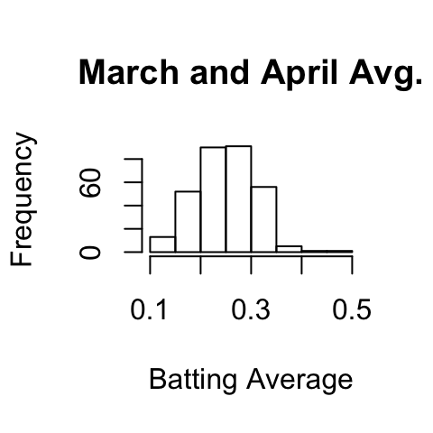

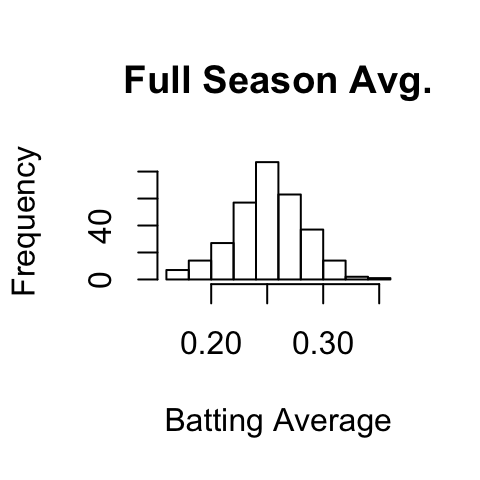

```r
#implementing various histograms for variable distribution.

hist(batting$MarApr_AB, xlab = "March and April At Bats", main = "At Bats")

hist(batting$MarApr_H, xlab = "March and April Hits", main = "Hits")

hist(batting$MarApr_AVG, xlab = "Batting Average", main = "March and April Avg." )

hist(batting$FullSeason_AVG, xlab = "Batting Average", main = "Full Season Avg." )
```

Referencing the plots above, Even though everyone’s data is only from the months of March and April, not everyone can be viewed as equal given the wide range of opportunities/At Bats as well as discrepancy in the number of hits in March and April. Furthermore, it is important to note Full Season Batting Averages, which will be our response variable, is approximately normally distributed given the bell shaped curve. Also, the range of Batting Averages is much wider for the first month of the season then Full Season Averages, suggesting regression to the mean which can be seen in this next plot:

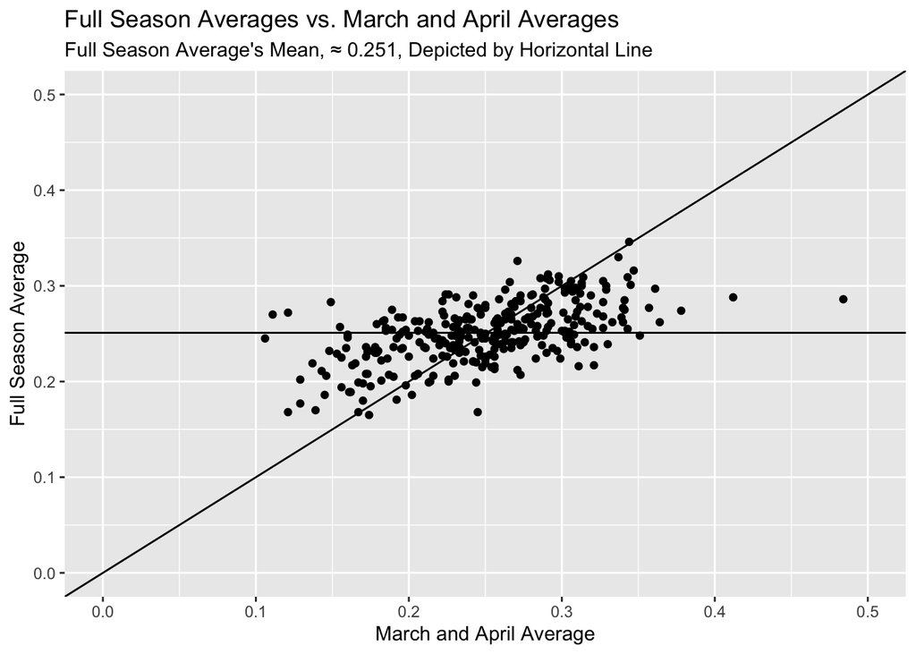

```r
# comparing March April Batting Averages to Full Season Averages

batting%>%
  ggplot(aes(x = MarApr_AVG, y = FullSeason_AVG)) +

# each point is a player

  geom_point() +

#set x and y to have the same range
  ylim(0, 0.5) +
  xlim(0,0.5)+

# depicts y = x relationship
  geom_abline(intercept = 0, slope = 1) +

# depicts the horizontal mean line in the graphic

  geom_hline(yintercept = mean(batting$FullSeason_AVG)) +
  labs(title = "Full Season Averages vs. March and April Averages",
       subtitle =  "Full Season Average's Mean, ≈ 0.251, Depicted by Horizontal Line",
       x = "March and April Average",
       y = "Full Season Average")
```

Thus, to aid in my predictions, I added data on the the player’s lifetime batting average until the beginning of the 2018 season because it is a measure of past success and can in the long run assess a players true batting ability. The data also comes from Fangraphs. It consists of every player’s career numbers from 2000-2017. I had to pick this range due to players like Albert Pujols and Jose Reyes who are in the dataset that have been playing since the early 2000s. Be careful because their are some players from our original dataset who have the same name as another MLB player from this time period. I manually erased these values. Furthermore, there are a few 2018 rookies in the dataset which have Na values for their Lifetime Batting Average. This can be problem when building the model. My solution was to fill Na values with the mean Lifetime Batting Average for the datset.

```r
#joining the new data to the existing dataset by player name.

batting_full<-batting%>%left_join(lifetime_avg, by = "Name")%>%arrange(Name)

#manually need to take out these rows. They are players who happened to have same names
# as the players in our dataset. After the dataset is 309 rows again.

batting<- batting_full[-c(73, 80, 171), ]

#There are a few rookies with no Lifetime Average. Filling in Na values with the mean of the column

batting$Lifetime_AVG<-na.aggregate(batting$Lifetime_AVG)
```

# Methodology

For my predictions, I would have liked to use James Stein Estimators; however, I would not be able to follow the methods of analysis similar to Bradley Efron and Carl Morris. Carl Morris stated that “Stein’s estimator required approximate normality (satisfied by a sufficient sample size for each batter), and it was designed only to work for equal variances.” Equal variance would be achieved by everyone having the same number of at bats; however, there is a wide distribution of at bats in this dataset.

Thus, I decided upon using a Random Forest Model to make my predictions. I believe its power and flexibility to be used for both classification and regression will be benefitial to making the predictions. Furthermore, I chose the random forest model because each decision tree is built on a subset of random features. Thus, I do not need to worry about overfitting and I can include many of the March and April batting variables.

I will break the data into two subsets (70,30) to train as well as test the model. Using the random forest model that will be bootstrapped to create a “forest” of decision tress from the training subset, I will predict final season batting averages for the testing subset. From here, I will visualize the predicted values as well as compare them to the true final season batting averages. To test the overall accurancy of the prediction, I will calculate the Root Mean Square Error, the standard deviation of residuals. This is a good metric because it will tell how concetrated the data is around the line of best fit.

Below is the code I used to impliment the random forest model:

```r
# set seed to replicate results
set.seed(1234)

# breaking my data into a training and testing samples

sample <-
  sample.int(n = nrow(batting),
             size = floor(.7 * nrow(batting)),
             replace = FALSE)
trainer <- batting[sample,]
tester <- batting[-sample,]

#Necessary functions to fix column names that R has trouble reading as variables
# For example anything that has a % in its header from the dataset will be changed to "."
names(trainer) <- make.names(names(trainer))
names(tester) <- make.names(names(tester))

#will not need these columns in the random forest model.

trainer <- trainer %>% select(-playerid,-Team)

#impliments the random forest model on every column in the datset except the first, which is the name of
# each playeer.

fit_rf <- randomForest(FullSeason_AVG ~ .,
                       data = trainer[-c(1)])

#produces summary of the model.
fit_rf
```

```
##
## Call:
##  randomForest(formula = FullSeason_AVG ~ ., data = trainer[-c(1)])
##                Type of random forest: regression
##                      Number of trees: 500
## No. of variables tried at each split: 8
##
##           Mean of squared residuals: 0.0006718835
##                     % Var explained: 35.65
```

# Predictions

Here is how I used the random forest model, fit_rf, to make full season batting average predictions. I created a dataframe with these predictions as well as other relevant variables for further analysis.

```r
#creating predictions on the tester subset

rfpredictions = predict(fit_rf, newdata = tester)

#buidling a dataframe for prediction analysis

prediction = data.frame(Name = tester$Name,
                        FullSeason_AVG = tester$FullSeason_AVG,
                        prediction = rfpredictions,
                        MarApr_AVG = tester$MarApr_AVG)

head(prediction)
```

```
##              Name FullSeason_AVG prediction MarApr_AVG
## 1    A.J. Pollock          0.257  0.2836781      0.291
## 2   Aaron Altherr          0.181  0.2389087      0.192
## 3     Adam Duvall          0.195  0.2315422      0.175
## 4    Adam Frazier          0.277  0.2562816      0.250
## 5   Albert Pujols          0.245  0.2644864      0.248
## 6 Alcides Escobar          0.231  0.2497659      0.237
```

Also a few graphics:

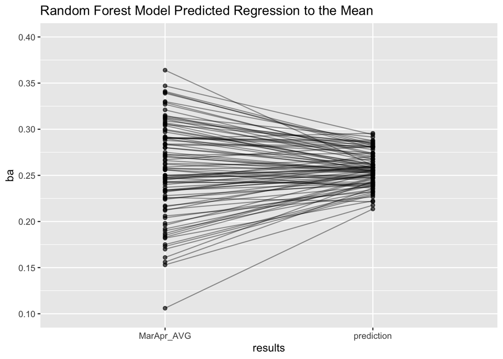

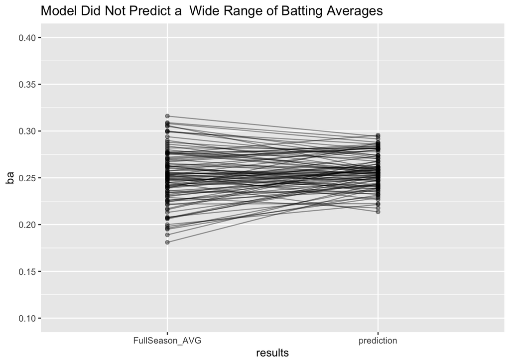

```r
# visualizing the predictions

prediction%>%
  gather(prediction, MarApr_AVG, key = results, value = ba)%>%
  ggplot(aes(x = results, y = ba, group = Name)) +
  geom_point(alpha = 0.4) +
  geom_line(alpha = 0.4) +
  scale_y_continuous(breaks = seq(0.1,0.4,0.05), limits = c(0.1,0.4))  +
  geom_point(alpha = 0.4) +
  labs(title = "Random Forest Model Predicted Regression to the Mean")

prediction%>%
  gather(FullSeason_AVG, prediction, key = results, value = ba)%>%
  ggplot(aes(x = results, y = ba, group = Name)) +
  geom_point(alpha = 0.4) +
  geom_line(alpha = 0.4) +
  scale_y_continuous(breaks = seq(0.1,0.4,0.05), limits = c(0.1,0.4)) +
  labs(title = "Model Did Not Predict a  Wide Range of Batting Averages", subtitle = )
```

Although I did not use the James_Stein EStimator approach, the results of the random forest model were very similar. The “shrinking” is very evident in these graphs by how the predictions funnel in towards the mean of the dataset. A criticism however, could be that there was to much shrinkage evident by the range of values the random forest model predicted. There were no values above 0.300 or below 0.200, thus the model struggled to predict both extremes.

Also, calculating the RMSE:

```r
#adding two columns to the prediction dataframe

prediction<-prediction%>%
  mutate(se = (FullSeason_AVG - prediction)^2,
         difference = FullSeason_AVG - prediction)

# computing the RMSE
prediction%>%
  summarise(RMSE = sqrt(mean(se)))
```

```
##       RMSE
## 1 0.023772
```

```r
#displays the very worst predictions based on how far it was from true value.

prediction%>%
  arrange(desc(abs(difference)))%>% head(5)
```

```
##            Name FullSeason_AVG prediction MarApr_AVG          se
## 1 Aaron Altherr          0.181  0.2389087      0.192 0.003353421
## 2    Jose Reyes          0.189  0.2437421      0.161 0.002996694
## 3 Gregor Blanco          0.217  0.2682724      0.321 0.002628859
## 4   Jefry Marte          0.216  0.2651102      0.311 0.002411815
## 5 Carlos Correa          0.239  0.2874613      0.330 0.002348498
##    difference
## 1 -0.05790873
## 2 -0.05474207
## 3 -0.05127240
## 4 -0.04911023
## 5 -0.04846130
```

```r
#displays best predictions meaning predictions closest to the Full Season Average.

prediction%>%
  arrange(abs(difference)) %>% head(5)
```

```
##                Name FullSeason_AVG prediction MarApr_AVG           se
## 1    Starlin Castro          0.278  0.2778303      0.312 2.879809e-08
## 2        Manny Pina          0.252  0.2522897      0.196 8.394540e-08
## 3 Robinson Chirinos          0.222  0.2223800      0.182 1.443747e-07
## 4  Andrew McCutchen          0.255  0.2555962      0.212 3.554942e-07
## 5     Marcus Semien          0.255  0.2543953      0.275 3.656218e-07
##      difference
## 1  0.0001697000
## 2 -0.0002897333
## 3 -0.0003799667
## 4 -0.0005962333
## 5  0.0006046667
```

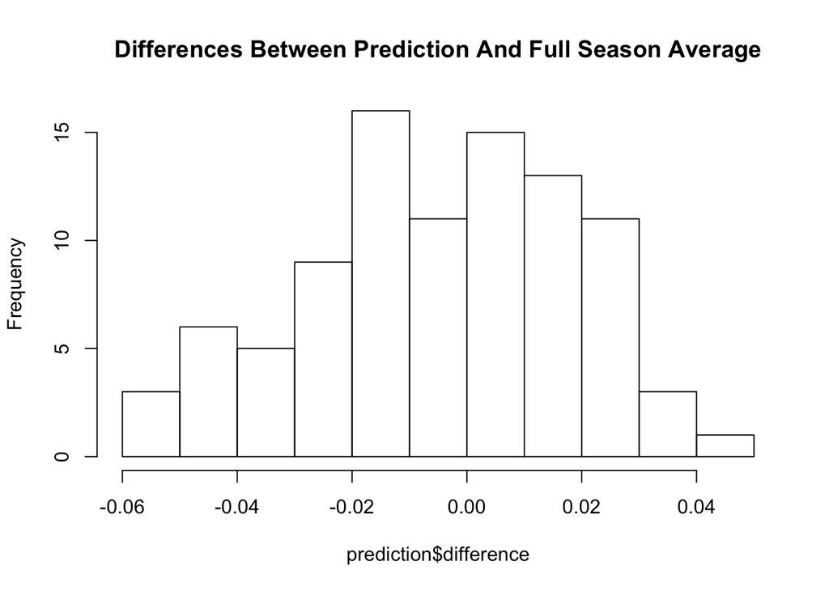

```r
#displays plot of the distribution of differences.

hist(prediction$difference, main = "Differences Between Prediction And Full Season Average")
```

```r
#calculation to find how much many predictions distances from true value falls within -0.02 and 0.02.

prediction%>%mutate(within_0.02 = case_when(difference > -0.02 & difference < 0.02 ~ 1,
                                            TRUE ~ 0))%>%
  summarise(within_0.02 = sum(within_0.02)/n())
```

```
##   within_0.02
## 1   0.5913978
```

# Conclusions

I believe the data is very hard to model given how small the dataset is and the range of predictions that needed to be made. It is extremely hard to predict Charlie Culberson’s average after only having 3 hits in 27 at bats in the same model as George Spring who had 32 hits in 120 at bats. Even harder, Springer stayed at right about this batting average while Culberson went on to hit 0.270 in 2018. There are so many combinations of hits and at bats in March and April and final season batting averages such as this in such a small dataset that I believe any model would struggle to predict extremely accurate batting averages. However, all in all, the random forest model made fairly decent predictions. The predictions are not always exact; however, they put us in the ballpark. Furthermore, the model adheres to the principle of regression to the mean, which Bradley Efron and Carl Morris proved to be relevant in the prediction of full season batting averages using James Stein Estimators.

Further iterations of this analysis can include more fine tuning of the random forest model. Also, I could try to incorporate more hitting data in the model such as Launch Angle, Exit Velocity, and Hard Hit %. Furthermore, a Multilevel Bayesian Model may provide more accurate predictions than the random forest model I chose to use. Multilevel models are regression models that “incorporate group-specific effects”, which would serve well with regression to the mean. I was not able to learn or impliment a Multilevel Bayesian Model given the short period of time to work on the assignment (however, they will be a focus of one of my classes next semester).

All the code generated for this project as well as the .rmd file can be viewed [here](https://github.com/diegomartinez1221/predict_ba).